# Final Project: Student Performance Analysis

Evan Holmes, Bridget Koehler, Hugo Valent

5/19/2019

# Introduction to the data set

The data we use in this project comes from two datasets on Portuguese students and their performance in math (395 observations) and Portuguese (649 observations) courses. 382 students belong to both datasets and while we mainly work with the datasets separately, some of our analysis involves the joint dataset. There are 33 predictors in both datasets involving information such as school, sex, age, information about the students’ study and lifestyle habits, family details, and three grades. We acknowledge that the earlier grades (G1, G2) are helpful in predicting the final grade (G3) and we explore models with and without G1 and G2. The full list and description of predictors can be found at https://archive.ics.uci.edu/ml/datasets/Student+Performance.

We first perform Exploratory Data Analysis to understand relationships between predictors and grades, involving interesting trends between grades and school, parents’ jobs, alcohol consumption, health, and family relationships.

Then we move into building a linear model to predict G3 to get an idea of what kind of results we can obtain from a basic model.

We then attempt to explore and answer various questions including: What are the most important variables in predicting a student’s grade? Which variables have a similar effect in predicting grades? What attributes are common among similarly performing students? What attributes are most helpful in predicting the school a student attends? What attributes are most helpful in predicting internet access?

To investigate these questions, we used a variety of prediction methods and models including clustering, random forests, lasso, subset selection, and PCA.

```r
d1=read.table("~/Downloads/student/student-mat.csv",sep=";",header=TRUE)
d2=read.table("~/Downloads/student/student-por.csv",sep=";",header=TRUE)
d3=merge(d1,d2,by=c("school","sex","age","address","famsize","Pstatus",
                    "Medu","Fedu","Mjob","Fjob","reason","nursery","internet"))
d1 = as.data.frame(d1)
d2 = as.data.frame(d2)
d3 = as.data.frame(d3)
```

# Explatory Data Analysis (EDA)

We will create various plots to understand the relationships between predictors in both the math and Portuguese data sets.

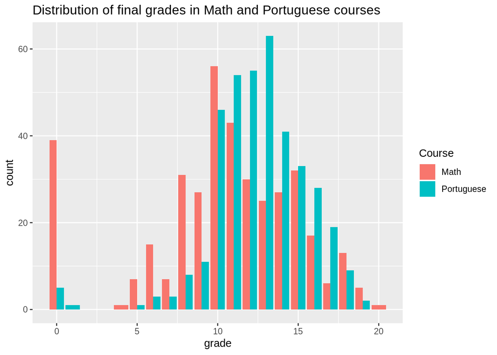

```r
d3 %>%
  gather(`G3.x`, `G3.y`, key="course", value="grade") %>%
  ggplot() +
  geom_bar(aes(x=grade, fill=course), position="dodge") +
  ggtitle("Distribution of final grades in Math and Portuguese courses") +
  scale_fill_discrete(name = "Course", labels = c("Math", "Portuguese"))
```

```r
c(mean(d3$G3.x), mean(d3$G3.y))
```

```
## [1] 10.38743 12.51571
```

As seen in the plot and the summary statistics, the mean final grades of the students (who are in both the math and Portuguese courses) in the Portuguese course are higher than the math course.

```r
c(mean(d1$G3), mean(d2$G3))
```

```
## [1] 10.41519 11.90601
```

While the mean final grade of all the students in math (10.42) is not much different than the subset of students in both math and Portuguese (10.39), the mean final grades of the subset of Portuguese students is slightly different (11.91 total vs 12.52 subset). This makes sense because almost all of the students in the math course are in the combined dataset, but there are about 300 additional students in Portuguese dataset.

```r
c(mean(d1$G1), mean(d1$G2), mean(d1$G3))
```

```
## [1] 10.90886 10.71392 10.41519
```

```r
c(mean(d3$G1.x), mean(d3$G2.x), mean(d3$G3.x))
```

```
## [1] 10.86126 10.71204 10.38743
```

For all students in math as well as the subset of math students the mean grade slightly decreases as the semester progresses.

```r
c(mean(d2$G1), mean(d2$G2), mean(d2$G3))
```

```
## [1] 11.39908 11.57011 11.90601
```

```r
c(mean(d3$G1.y), mean(d3$G2.y), mean(d3$G3.y))
```

```
## [1] 12.11257 12.23822 12.51571
```

With Portuguese, the mean grade slightly increases as the semester progresses for both the Portuguese students in the joint dataset (d3) as well as all Portuguese students (d2).

```r
mathGrades <- d1 %>%
  gather(`G1`, `G2`, `G3`, key="semester", value="grade") %>%
  ggplot() +
  geom_bar(aes(x=grade, fill=semester), position="dodge") +
  ggtitle("Distribution of three grades in Math")
```

```r
portGrades <- d2 %>%
  gather(`G1`, `G2`, `G3`, key="semester", value="grade") %>%
  ggplot() +
  geom_bar(aes(x=grade, fill=semester), position="dodge") +
  ggtitle("Distribution of three grades in Portuguese")
```

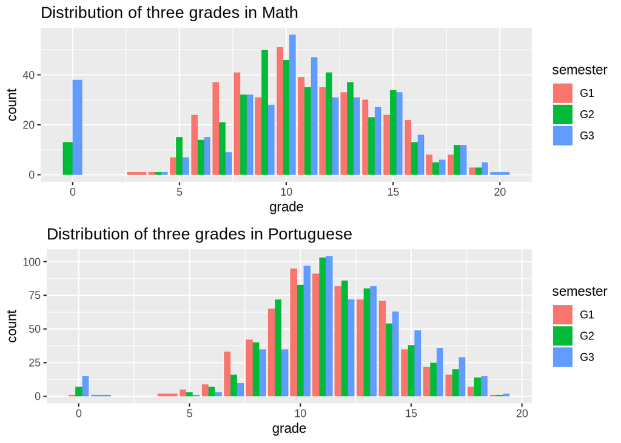

```r
grid.arrange(mathGrades, portGrades)
```

Comparing the grade distributions of math and Portuguese, we see the increasing trend in Portuguese. We observe that the decreasing trend in math is most likely due to the increasing number of students with a grade of 0. These plots inform us that G1 and G2 would be effective in predicting G3. The summary statistics above tell us that there are not drastic differences in grades between the subsets and all students in both math and Portuguese.

```r
mathGrades2 <- ggplot(d1) +
  geom_bar(aes(x=school, fill=as.factor(G3)), position="dodge") +
  ggtitle("Distribution of Math grades by school") +
  theme(legend.position = "none")

portGrades2 <- ggplot(d2) +
  geom_bar(aes(x=school, fill=as.factor(G3)), position="dodge") +
  ggtitle("Distribution of Portuguese grades by school") +
  theme(legend.position = "none")
```

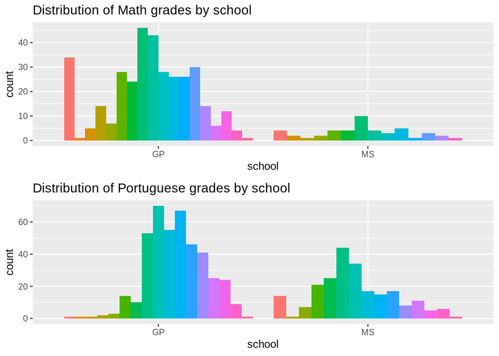

```r
grid.arrange(mathGrades2, portGrades2)
```

We see similar trends between both schools in math and Portuguese. In general, the mean grades tend to be higher in the Gabriel Pereira (GP) school.

```r
schoolMath <- ggplot(d1, aes(x=G3)) +
  geom_density(aes(color=school)) +
  ggtitle("Distribution of Math students' grades by school")

schoolPort <- ggplot(d2, aes(x=G3)) +
  geom_density(aes(color=school)) +
  ggtitle("Distribution of Portuguese students' grades by school")
```

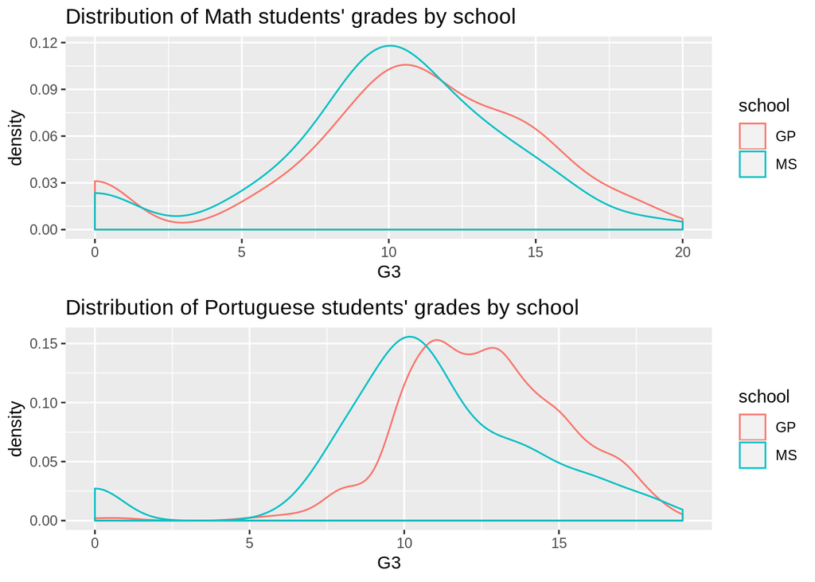

```r
grid.arrange(schoolMath, schoolPort)
```

The distribution of math grades between the two schools is similar, but the students from Gabriel Pereira outperform those from Mousinho da Silveira in Portuguese.

```r
addressMath <- ggplot(d1, aes(x=G3)) +
  geom_density(aes(color=address)) +
  ggtitle("Distribution of Math students' grades by address")

addressPort <- ggplot(d2, aes(x=G3)) +
  geom_density(aes(color=address)) +
  ggtitle("Distribution of Portuguese students' grades by address")
```

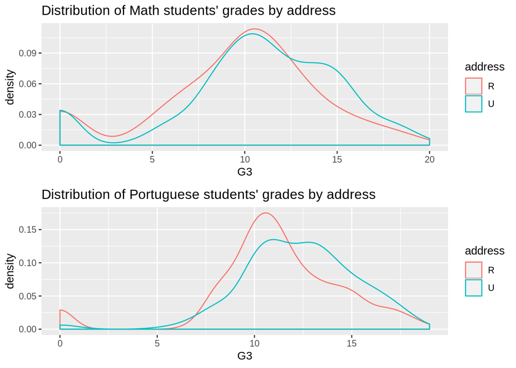

```r
grid.arrange(addressMath, addressPort)
```

Students living in more urban areas tend to outperform students from rural areas in both math and Portuguese. Since Gabriel Pereira is in a more urban location and Mousinho da Silveira is more rural, this plot lines up with the previous plot.

```r
mjobMath <- ggplot(d1, aes(x=G3)) +
  geom_density(aes(color=as.factor(Mjob))) +
  ggtitle("Distribution of Math students' grades by mothers' job")

mjobPort <- ggplot(d2, aes(x=G3)) + #d2
  geom_density(aes(color=as.factor(Mjob))) + #Fjob
  ggtitle("Distribution of Portuguese students' grades by mothers' job")
```

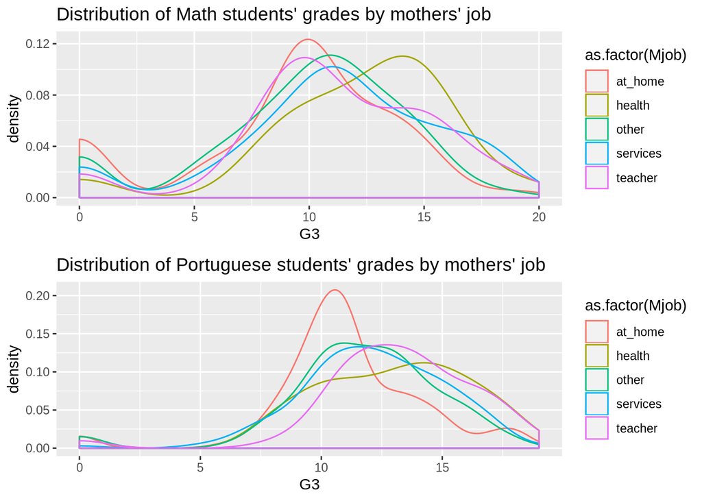

```r
grid.arrange(mjobMath, mjobPort)
```

We see that math students whose mothers have jobs in health outperform other students. Portuguese students whose mothers stay at home seem to underperform compared to other students.

```r
fjobMath <- ggplot(d1, aes(x=G3)) +
  geom_density(aes(color=as.factor(Fjob))) +
  ggtitle("Distribution of Math students' grades by fathers' job")

fjobPort <- ggplot(d2, aes(x=G3)) + #d2
  geom_density(aes(color=as.factor(Fjob))) +
  ggtitle("Distribution of Portuguese students' grades by fathers' job")
```

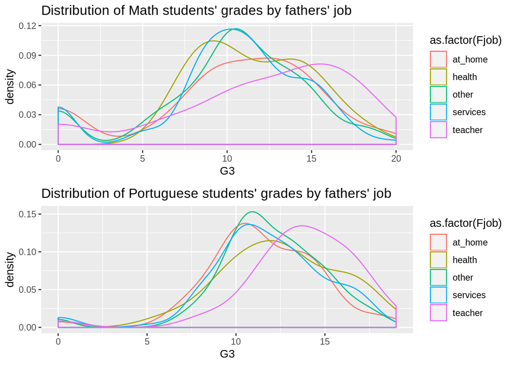

```r
grid.arrange(fjobMath, fjobPort)
```

For both math and Portuguese, students whose fathers are teachers outperform other students.

```r
famMath <- ggplot(d1, aes(x=G3)) +
  geom_density(aes(color=as.factor(famrel))) +
  ggtitle("Distribution of Math students' grades by family relationships")

famPort <- ggplot(d2, aes(x=G3)) +
  geom_density(aes(color=as.factor(famrel))) +
  ggtitle("Distribution of Portuguese students' grades by family relationships")
```

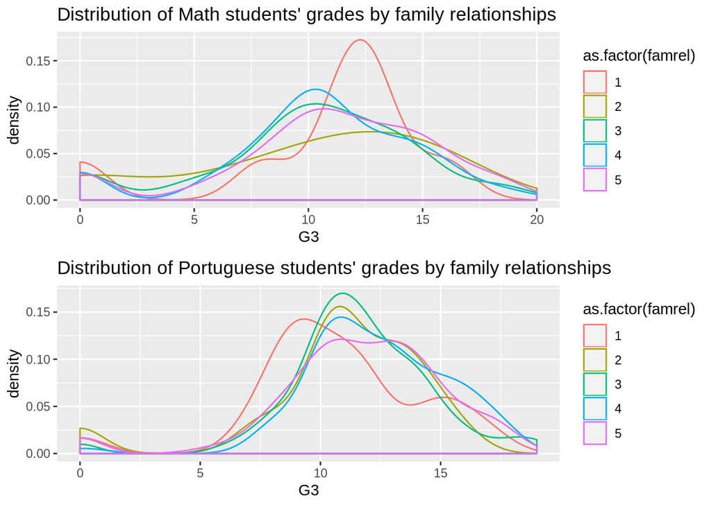

```r
grid.arrange(famMath, famPort)
```

Interestingly, the average grade of students with the worst family relationships is higher than students with better relationships for math. But the opposite is true for Portuguese. Perhaps poor communication at home influences a student’s understanding of language.

Other trends that we found that are not surprising:

- students with the highest travel time have lower average grades in both math and Portuguese.
- higher grades are attributed to more study time, less previous failures, and intent to pursue higher education.
- students receiving extra academic support have lower average grades.

# Predicting student grades

## Linear model

```r
mattrain <- sample(1:nrow(d1), (nrow(d1)/2))
portrain <- sample(1:nrow(d2), (nrow(d2)/2))
train.mat = d1[mattrain,]
train.mat = subset(train.mat, select = -c(G1,G2))
train.por = d1[portrain,]
train.por = subset(train.por, select = -c(G1,G2))

test.mat = d1[-mattrain,]
test.mat = subset(test.mat, select = -c(G1,G2))
test.por = d1[-portrain,]
test.por = subset(test.por, select = -c(G1,G2))
```

Here are the actual models!

```r
mod_math <- lm(scale(G3) ~ . , data=train.mat)
mod_por <- lm(scale(G3) ~ . , data=train.por)
```

How well do they predict on their own test sets? How well do they predict for each other’s test sets?

```r
test.mat.preds <- predict(mod_math, data=test.mat)
test.por.preds <- predict(mod_por, data=test.por)

#MSE
mean((test.mat$G3[-1] - test.mat.preds)^2)
```

```
## [1] 128.445
```

```r
mean((test.por$G3 - test.por.preds)^2)
```

```
## [1] 129.0982
```

```r
## predict each other
test.mat.porpreds <- predict(mod_math, data=test.por)
test.por.matpreds <- predict(mod_por, data=test.mat)

#MSE
mean((test.mat$G3[-1] - test.mat.porpreds)^2)
```

```
## [1] 128.445
```

```r
mean((test.por$G3 - test.por.matpreds)^2)
```

```
## [1] 129.0982
```

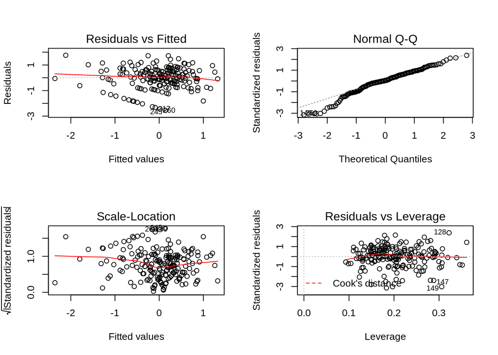

```r
# Check conditions
par(mfrow=c(2,2))
plot(mod_math)
```

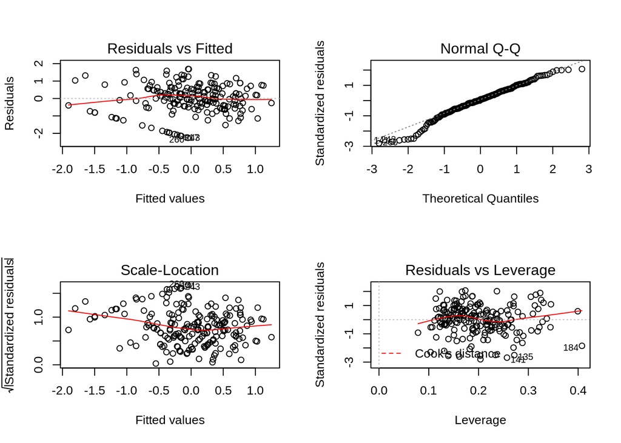

```r
par(mfrow=c(1,1))

par(mfrow=c(2,2))
plot(mod_por)
```

```r
par(mfrow=c(1,1))
```

```r
summary(mod_math)
```

```
##
## Call:
## lm(formula = scale(G3) ~ ., data = train.mat)
##
## Residuals:
##      Min       1Q   Median       3Q      Max
## -2.55109 -0.38603  0.03426  0.52999  1.75745
##
## Coefficients:
##                    Estimate Std. Error t value Pr(>|t|)
## (Intercept)       1.1981533  1.5305472   0.783  0.43491
## schoolMS         -0.1456490  0.2579459  -0.565  0.57312
## sexM              0.1815509  0.1699414   1.068  0.28702
## age              -0.0997690  0.0698463  -1.428  0.15516
## addressU         -0.0022785  0.1861829  -0.012  0.99025
## famsizeLE3        0.1226537  0.1548093   0.792  0.42939
## PstatusT          0.0508702  0.2443241   0.208  0.83534
## Medu              0.1349343  0.1092138   1.236  0.21849
## Fedu             -0.0766780  0.0907798  -0.845  0.39959
## Mjobhealth        0.3698678  0.3650858   1.013  0.31257
## Mjobother        -0.0944023  0.2475052  -0.381  0.70341
## Mjobservices      0.1343810  0.2724568   0.493  0.62255
## Mjobteacher      -0.0343896  0.3363119  -0.102  0.91868
## Fjobhealth       -0.1126618  0.5059219  -0.223  0.82407
## Fjobother        -0.4789196  0.4077581  -1.175  0.24197
## Fjobservices     -0.4120420  0.4115879  -1.001  0.31832
## Fjobteacher       0.2365895  0.4843188   0.488  0.62588
## reasonhome        0.1423727  0.1847104   0.771  0.44199
## reasonother       0.2046370  0.2496543   0.820  0.41364
## reasonreputation  0.0987543  0.1886983   0.523  0.60147
## guardianmother    0.0836801  0.1753789   0.477  0.63393
## guardianother     0.5323285  0.3062792   1.738  0.08416 .
## traveltime        0.0158615  0.1105517   0.143  0.88610
## studytime         0.0974075  0.0957885   1.017  0.31076
## failures         -0.3805038  0.1209908  -3.145  0.00199 **
## schoolsupyes     -0.3864053  0.2366052  -1.633  0.10445
## famsupyes        -0.1265930  0.1566434  -0.808  0.42022
## paidyes          -0.0430653  0.1525988  -0.282  0.77815
## activitiesyes    -0.0971923  0.1462184  -0.665  0.50721
## nurseryyes       -0.2474658  0.1828002  -1.354  0.17776
## higheryes         0.7677541  0.4074702   1.884  0.06139 .
## internetyes       0.0551447  0.2178317   0.253  0.80048
## romanticyes      -0.0589892  0.1567740  -0.376  0.70722
## famrel            0.1086548  0.0793209   1.370  0.17270
## freetime         -0.1372228  0.0779291  -1.761  0.08021 .
## goout            -0.0676386  0.0793378  -0.853  0.39521
## Dalc              0.0087219  0.1095075   0.080  0.93662
## Walc              0.0334009  0.0806724   0.414  0.67942
## health           -0.0139049  0.0590527  -0.235  0.81415
## absences          0.0001987  0.0104272   0.019  0.98482
## ---
## Signif. codes:  0 '***' 0.001 '**' 0.01 '*' 0.05 '.' 0.1 ' ' 1
##
## Residual standard error: 0.8978 on 157 degrees of freedom
## Multiple R-squared:  0.3543, Adjusted R-squared:  0.194
## F-statistic: 2.209 on 39 and 157 DF,  p-value: 0.0003266
```

```r
summary(mod_por)
```

```
##
## Call:
## lm(formula = scale(G3) ~ ., data = train.por)
##
## Residuals:
##      Min       1Q   Median       3Q      Max
## -2.25401 -0.43073  0.05571  0.55268  1.69191
##
## Coefficients:
##                   Estimate Std. Error t value Pr(>|t|)
## (Intercept)       3.167871   1.440921   2.199  0.02935 *
## schoolMS          0.639978   0.282584   2.265  0.02487 *
## sexM              0.277412   0.163357   1.698  0.09141 .
## age              -0.203240   0.070092  -2.900  0.00426 **
## addressU          0.045013   0.194979   0.231  0.81772
## famsizeLE3       -0.017621   0.154165  -0.114  0.90914
## PstatusT         -0.405712   0.250079  -1.622  0.10670
## Medu              0.076275   0.113039   0.675  0.50080
## Fedu             -0.061098   0.095977  -0.637  0.52530
## Mjobhealth        0.346315   0.405160   0.855  0.39396
## Mjobother         0.280042   0.242964   1.153  0.25079
## Mjobservices      0.526769   0.264981   1.988  0.04852 *
## Mjobteacher       0.096550   0.351244   0.275  0.78376
## Fjobhealth        0.091747   0.498887   0.184  0.85432
## Fjobother        -0.034890   0.384750  -0.091  0.92786
## Fjobservices     -0.007013   0.392272  -0.018  0.98576
## Fjobteacher       0.290843   0.461734   0.630  0.52966
## reasonhome       -0.239316   0.188420  -1.270  0.20589
## reasonother       0.121351   0.304186   0.399  0.69047
## reasonreputation  0.163565   0.186760   0.876  0.38245
## guardianmother    0.179736   0.170842   1.052  0.29436
## guardianother     0.980275   0.389812   2.515  0.01290 *
## traveltime       -0.072574   0.104850  -0.692  0.48984
## studytime        -0.010183   0.092806  -0.110  0.91277
## failures         -0.385093   0.118373  -3.253  0.00139 **
## schoolsupyes     -0.263891   0.216594  -1.218  0.22488
## famsupyes        -0.221587   0.152403  -1.454  0.14792
## paidyes           0.258059   0.159685   1.616  0.10805
## activitiesyes    -0.060021   0.148718  -0.404  0.68706
## nurseryyes        0.083606   0.180052   0.464  0.64303
## higheryes        -0.037272   0.370703  -0.101  0.92004
## internetyes       0.211419   0.214672   0.985  0.32619
## romanticyes      -0.253494   0.151635  -1.672  0.09653 .
## famrel            0.016514   0.078816   0.210  0.83431
## freetime         -0.031528   0.077954  -0.404  0.68643
## goout            -0.099016   0.072094  -1.373  0.17154
## Dalc              0.067885   0.097566   0.696  0.48758
## Walc              0.034528   0.079020   0.437  0.66273
## health            0.024930   0.049872   0.500  0.61785
## absences          0.021104   0.011130   1.896  0.05974 .
## ---
## Signif. codes:  0 '***' 0.001 '**' 0.01 '*' 0.05 '.' 0.1 ' ' 1
##
## Residual standard error: 0.9012 on 160 degrees of freedom
##   (124 observations deleted due to missingness)
## Multiple R-squared:  0.347,  Adjusted R-squared:  0.1879
## F-statistic:  2.18 on 39 and 160 DF,  p-value: 0.0003915
```

## SVM

We created a variable called ‘performance’ that creates three categories of performance: 1- high, 2-average, 3-low. Then we run the SVM algorithm to classify students based on the other available predictors. We found slightly better results using a polynomial and radial kernel, so we stuck with radial kernel.

```r
theCost <- 10

data.df <- d3[,c("school","sex","age","address","famsize","Pstatus","Medu","Fedu",
                 "Mjob","Fjob","reason","nursery","internet","G3.x","G3.y")]

data.df$mathperformance <- factor(ifelse(data.df$G3.x > 16, 1,
            ifelse(data.df$G3.x > mean(data.df$G3.x) & data.df$G3.x <= 16, 2, 3)))

data.df$porperformance <- factor(ifelse(data.df$G3.y > 16, 1,
            ifelse(data.df$G3.y > mean(data.df$G3.y) & data.df$G3.y <= 16, 2, 3)))

data.df$id <- 1:nrow(data.df)

test.sample <- sample(1:nrow(data.df), (nrow(data.df)/2))
test.df <- data.df[test.sample,]
data.df <- data.df[-test.sample,]

# Math model
mod.svm.math <- svm(mathperformance~.,
               data=subset(data.df,
               select=-c(id, porperformance, G3.x, G3.y)),
               kernel="radial",
               cost=theCost,
               scale=F)

# Portuguese model
mod.svm.por <- svm(porperformance~.,
               data=subset(data.df,
               select=-c(id, mathperformance, G3.x, G3.y)),
               kernel="radial",
               cost=theCost,
               scale=F)

test.df$predmath <- predict(mod.svm.math,
            data=subset(test.df, select=-c(id, porperformance, G3.x, G3.y)))
test.df$predpor <- predict(mod.svm.por,
            data=subset(test.df, select=-c(id, mathperformance, G3.x, G3.y, predmath)))

math_perf_accuracy <- round(1-mean(test.df$mathperformance != test.df$predmath), digits=2)

por_perf_accuracy <- round(1-mean(test.df$porperformance != test.df$predpor), digits=2)
```

The prediction accuracy for math performance is 0.46 and the prediction accuracy for Portuguese performance is 0.43. Since we have three categories, the accuracy is better than a coinflip, but not high at all. Though it seems better than the MSE in our linear model, which was in the hundreds for a quantitative variable with 20 as its maximum value.

# Clustering

To get a better understanding of the relationships between the predictors, we will perform unsupervised learning on the common variables across the two data sets using the hierarchical clustering algorithm and cutting the resulting tree at a reasonable height to obtain clusters.

Here we will be working with the combined data set, which consists of students who are in the math class as well as the Portuguese class.

Here’s the hierarchical cluster:

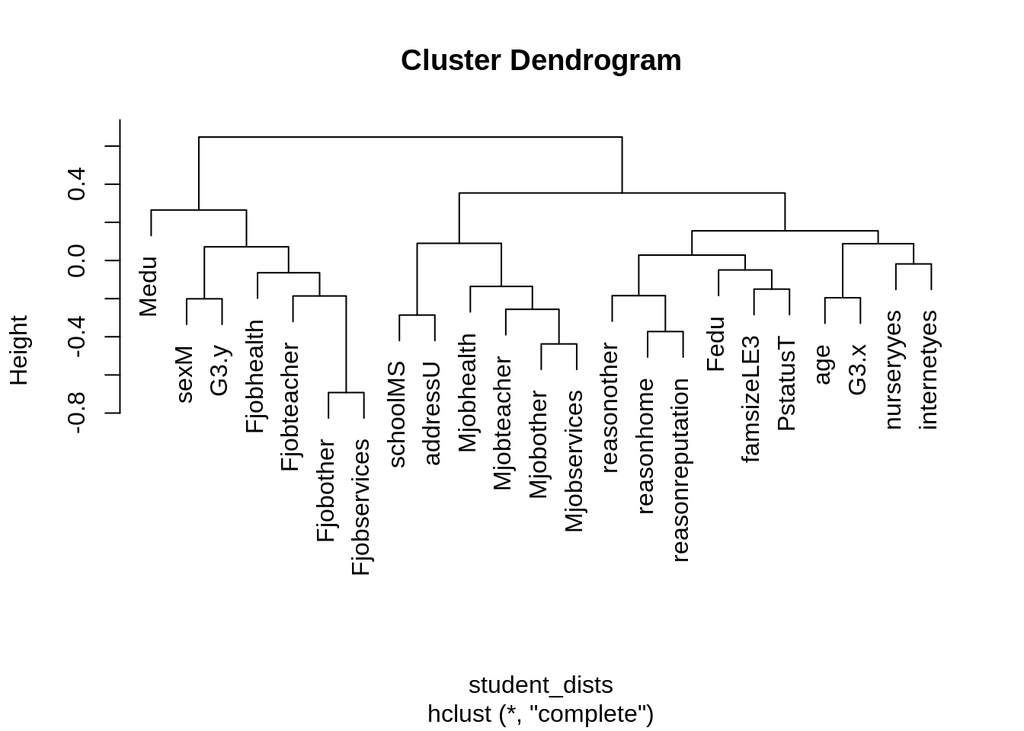

```r
hierclust <- hclust(student_dists)
plot(hierclust)
```

Now we perform the cut to obtain the clusters.

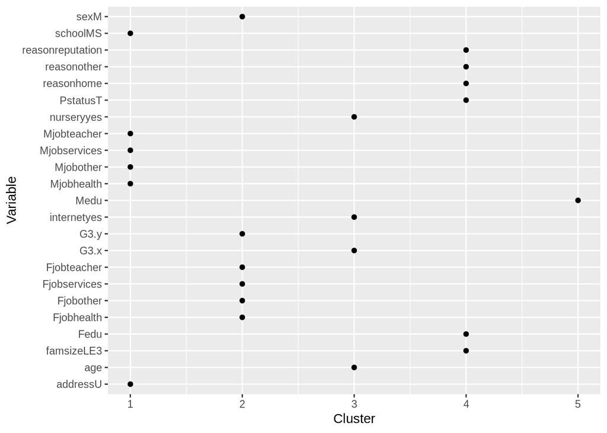

```r
cuttr <- cutree(hierclust, h=0.1)
simvars <- as.data.frame(cuttr)
colnames(simvars) <- "Cluster"
simvars$Variable <- names(cuttr)
simvars%>% ggplot()+
  geom_point(aes(Cluster, Variable))
```

Mother’s education and father’s job, along with sex of the student, seems to differentiate the student’s performance the most. It’s interesting to see some of the natural clusters of predictors that appear in this plot (things about the father, things about the mother). For math, we see that hierarchical clustering shows that the predictors age, access to nursery, and access to internet are clustered together. For Portuguese, we see that the occupation of the father and the male children are clustered together. How do these natural clusters compare with things from PCA?

# Variable analysis

## PCA

We will use PCA to visualize how the variables in both the math and Portuguese data sets relate to one another.

```r
mathStudents <- d1
portStudents <- d2
# convert predictors to numeric
for(i in colnames(mathStudents)){
    mathStudents[,i] <- as.numeric(mathStudents[,i])
    portStudents[,i] <- as.numeric(portStudents[,i])
}
```

```r
# scale
d1_pca <- data.frame(scale(mathStudents))
d2_pca <- data.frame(scale(portStudents))
```

```r
# initial clustering
K <- 5
mathMod.km <- kmeans(d1_pca,K,nstart=25)
portMod.km <- kmeans(d2_pca,K,nstart=25)
```

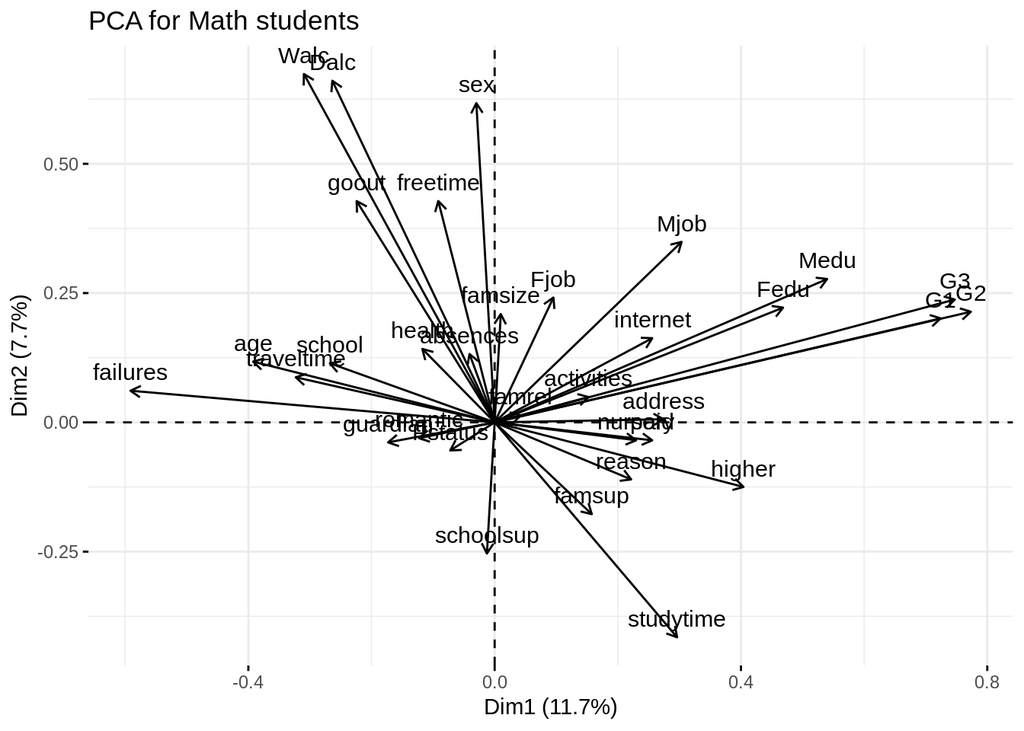

```r
# fviz_cluster - compute the principal components for math
mathMod.pc <- prcomp(d1_pca)
fviz_pca_var(mathMod.pc) +
  ggtitle("PCA for Math students")
```

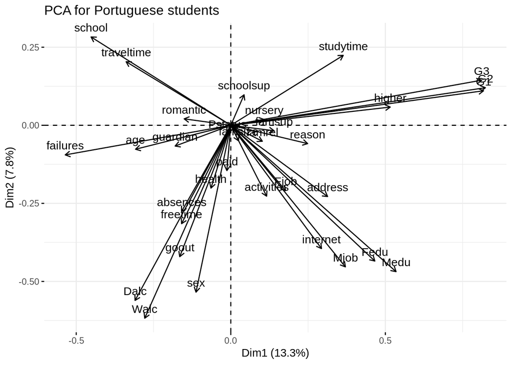

```r
# fviz_cluster - compute the principal components for Portuguese
portMod.pc <- prcomp(d2_pca)
fviz_pca_var(portMod.pc) +
  ggtitle("PCA for Portuguese students")
```

The trends and grouping of the predictors are similar across math and Portuguese. In one grouping we see travel time, failures, age, and school, guardian, and romantic. We saw earlier that GP is a higher performing school and there are less young students at MS. In EDA, we also observed that long travel time is correlated with lower grades, which could tie into number of failures. Note, however, that these clusters of predictors appear to differ from the clusters we found in the hierarchical clustering.

Another grouping includes Walc, Dalc, freetime, goout, health, absences. These all seem naturally related to each other. Students with more free time may be prone to go out and consume alcohol, which may impact their health and attendance.

The last larger grouping includes Medu, Fedu, Mjob, Fjob, higher, studytime, address, internet, reason, famrel, famsup, paid, and nursery. This grouping makes sense as parents’ education influences their careers, as well as their child’s study habits and education goals.

## Lasso

We’ll use lasso to build a model and identify the predictors that correspond to an optimal lambda value. We’ll compare these important predictors to the groupings we found in PCA and compare the MSE to our linear model.

```r
# select only numeric predictors since lasso is not compatible with factors
d1_lasso <- select_if(d1, is.numeric)
d2_lasso <- select_if(d2, is.numeric)

# build test and train data sets for math students
mysample <- sample(1:nrow(d1_lasso), nrow(d1_lasso)/2)
d1train.df <- drop_na(d1_lasso[mysample,])
d1test.df <- drop_na(d1_lasso[-mysample,])
x.d1train <- as.matrix(d1train.df[,-c(14,15,16)])
x.d1test <- as.matrix(d1test.df[,-c(14,15,16)])
y.d1train <- d1train.df[,16]
y.d1test <- d1test.df[,16]

# build test and train data sets for Portuguese students
mysample <- sample(1:nrow(d2_lasso), nrow(d2_lasso)/2)
d2train.df <- drop_na(d2_lasso[mysample,])
d2test.df <- drop_na(d2_lasso[-mysample,])
x.d2train <- as.matrix(d2train.df[,-c(14,15,16)])
x.d2test <- as.matrix(d2test.df[,-c(14,15,16)])
y.d2train <- d2train.df[,16]
y.d2test <- d2test.df[,16]
```

Build a grid of lambda values

```r
lambda.grid <- 10^seq(-3,1,length=100)
mod.lasso1 <- glmnet(x.d1train,y.d1train,alpha=1,intercept=F,lambda=lambda.grid)
mod.lasso2 <- glmnet(x.d2train,y.d2train,alpha=1,intercept=F,lambda=lambda.grid)
```

Plot of lasso model for Math students

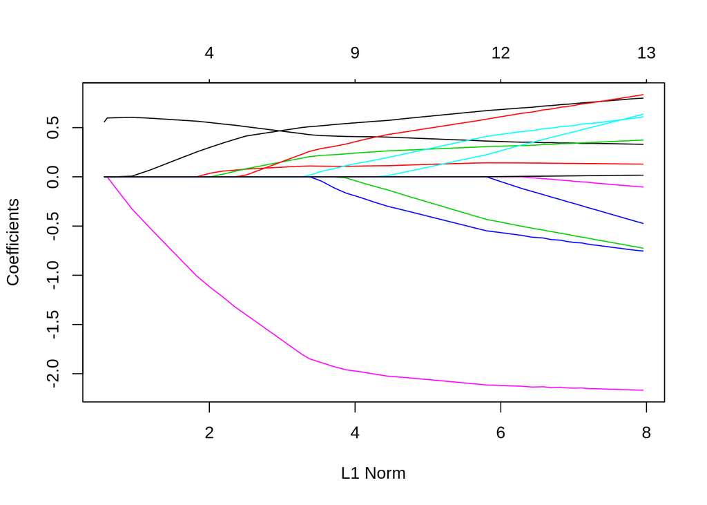

```r
plot(mod.lasso1)
```

We’ll see which predictors the optimal lambda value corresponds to below.

Plot of lasso model for Portuguese students

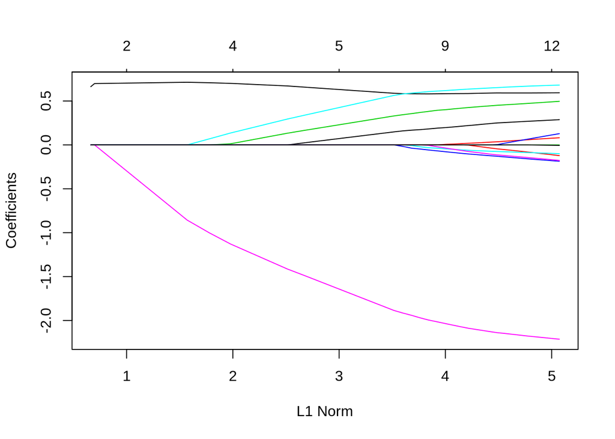

```r
plot(mod.lasso2)
```

We’ll see which predictors the optimal lambda value corresponds to below.

Use built-in cross-validation

```r
cv.lasso1 <- cv.glmnet(x.d1train,y.d1train,alpha=1,intercept=F,lambda=lambda.grid)
cv.lasso2 <- cv.glmnet(x.d2train,y.d2train,alpha=1,intercept=F,lambda=lambda.grid)
```

Optimal lambda value

```r
(lambda.opt1 <- cv.lasso1$lambda.min)
```

```
## [1] 0.1668101
```

```r
(lambda.opt2 <- cv.lasso2$lambda.min)
```

```
## [1] 0.1261857
```

Build optimal lasso model

```r
mod.lasso1 <- glmnet(x.d1train,y.d1train,alpha=1,intercept=F,lambda=lambda.opt1)
coef(mod.lasso1)[-1,1] # important predictors for determining grade for math
```

```
##        age       Medu       Fedu traveltime  studytime   failures
##  0.3800072  0.1318122  0.2901158 -0.4445893  0.3263074 -2.0758896
##     famrel   freetime      goout       Dalc       Walc     health
##  0.6304359  0.5207506 -0.3125280  0.0000000  0.1389058  0.0000000
##   absences
##  0.0000000
```

```r
mod.lasso2 <- glmnet(x.d2train,y.d2train,alpha=1,intercept=F,lambda=lambda.opt2)
coef(mod.lasso2)[-1,1] # important predictors for determining grade for Portuguese
```

```
##         age        Medu        Fedu  traveltime   studytime    failures
##  0.58452779  0.01891433  0.42568504  0.00000000  0.63617700 -2.08661730
##      famrel    freetime       goout        Dalc        Walc      health
##  0.22336807 -0.00393950  0.00000000 -0.10331312 -0.06045745 -0.07478851
##    absences
##  0.00000000
```

In the model with the optimal lambda value, it appears that age, mother education, family relationships, and free time correlate positively with grades for math, while failures correlate negatively. Absences has such a small coefficient that its value is negligible.

For Portuguese, age, mother and father education, study time, and family relationships correlate positively with grades, while failures and health correlate negatively.

The predictors chosen through lasso do not point in the same direction in the PCA plot explored earlier. This could be due to the fact that we only used the numeric predictors within the lasso models. However, the groupings found through lasso make sense as having similar effects on students’ grades.

Predict on training data with optimal lambda value

```r
# Math
pred.lasso.train1 <- predict(mod.lasso1,newx=x.d1train)
(mse.lasso.train1 <- mean((y.d1train-pred.lasso.train1)^2))
```

```
## [1] 16.79805
```

```r
# Portuguese
pred.lasso.train2 <- predict(mod.lasso2,newx=x.d2train)
(mse.lasso.train2 <- mean((y.d2train-pred.lasso.train2)^2))
```

```
## [1] 7.974251
```

Predict on testing data with optimal lambda value

```r
# Math
pred.lasso.test1 <- predict(mod.lasso1,newx=x.d1test)
(mse.lasso.test1 <- mean((y.d1test-pred.lasso.test1)^2))
```

```
## [1] 19.93554
```

```r
# Portuguese
pred.lasso.test2 <- predict(mod.lasso2,newx=x.d2test)
(mse.lasso.test2 <- mean((y.d2test-pred.lasso.test2)^2))
```

```
## [1] 8.739551
```

## Subset selection

We’ll use subset selection to find a subset of predictors which reduce MSE the most. We’ll compare this set of predictors to the groupings found in PCA and lasso.

```r
d1_subset <- d1 # math
d2_subset <- d2 # Portuguese
for(i in ncol(d1_subset)){
  d1_subset[,i] <- as.numeric(d1_subset[,i])
  d2_subset[,i] <- as.numeric(d2_subset[,i])
}
```

```r
d1_subset <- d1_subset[-c(31,32)] # remove g1 and g2
d2_subset <- d2_subset[-c(31,32)] # remove g1 and g2
numRows <- nrow(d1_subset)
train <- sample(1:numRows,numRows/2,rep=F)
# math
train1.df <- d1_subset[train,]
test1.df <- d1_subset[-train,]

# Portuguese
train2.df <- d2_subset[train,]
test2.df <- d2_subset[-train,]
```

Function for computing CV mse.

```r
mseCV <- function(data.df,kfolds=10){
  sampleSize <- nrow(data.df)
  folds <- sample(1:kfolds,sampleSize,rep=T)
  mse <- rep(0,kfolds)
  for(k in 1:kfolds){
    train.df <- data.df[folds !=k,]
    test.df <- data.df[folds==k,]
    mod <- lm(G3~.,data=train.df)
    vals <- predict(mod,newdata=test.df)
    mse[k] <- with(test.df,mean((G3-vals)^2))
  }
  mean(mse)
}
```

Compare mses of math and Portuguese with CV.

```r
# Math
mseCV(d1_subset)
```

```
## [1] 18.95604
```

```r
# Portuguese
mseCV(d2_subset)
```

```
## [1] 7.413482
```

Again we see a trend that the mse for predicting Portuguese grades is lower than math.

Now we will use a loop to continually add the predictor with the smallest mse in hopes of finding a subset of predictors that gives us the optimal mse. First, we will run the process for the math dataset.

```r
numPreds <- length(names(d1_subset))-1
allPreds <- 1:(numPreds)
currPreds <- c()
availPreds <- setdiff(allPreds,currPreds) # takes out currPreds from allPreds
maxPreds <- numPreds
minMSE <- numeric(maxPreds)

tot <- 0
while( tot < maxPreds){
  # add predictor which decreases MSE
  # The MSEs computed as we add each of the available predictors
  allMSE <- numeric(length(availPreds))
  ctr<-1
  for(id in availPreds){
    data.df <- d1_subset[,c(currPreds,id,numPreds+1)]
    mse <- mseCV(data.df,5)
    allMSE[ctr] <- mse
    ctr<-ctr+1
  }
  # Find the min mse
  id <- which.min(allMSE)
  # get the best predictor and MSE
  bestPred <- availPreds[id]
  bestMSE <- min(allMSE)
  # Add these into the collection
  currPreds <- c(currPreds,bestPred)
  tot <-tot+1
  minMSE[tot] <- bestMSE
  availPreds <- setdiff(allPreds,currPreds)
  #print(sprintf("Predictor Added: %s  MSE Value: %s",bestPred,bestMSE))
  #print(currPreds)
}
```

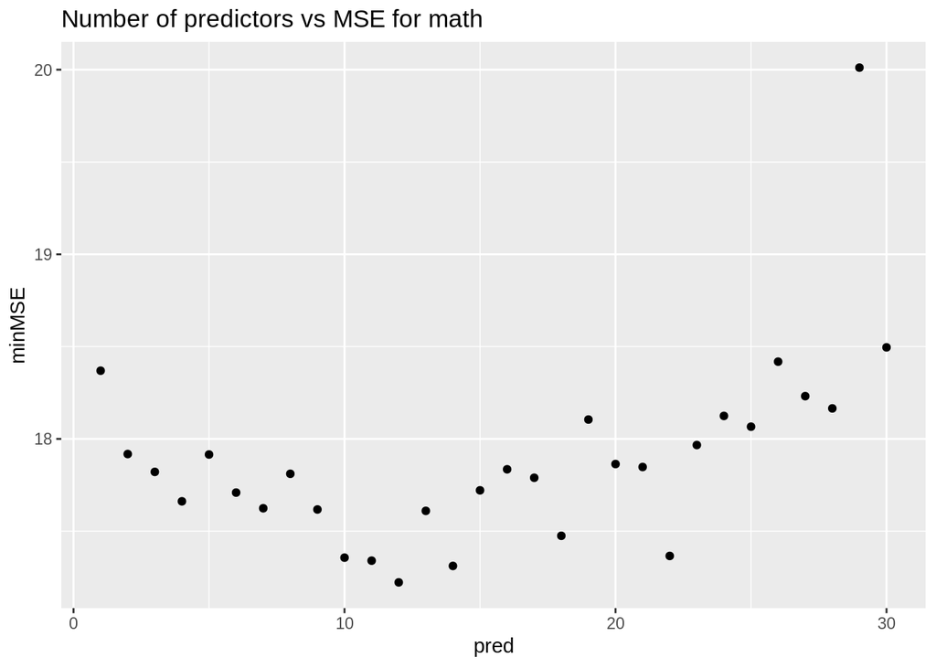

```r
data.frame(pred=1:maxPreds,minMSE) %>%
  ggplot()+
  geom_point(aes(pred,minMSE)) +
  ggtitle("Number of predictors vs MSE for math")
```

Which predictors are in the subset with the lowest MSE for math?

```r
bestPreds <- currPreds[1:which.min(minMSE)]
(bestPredNames <- names(d1_subset)[currPreds[1:which.min(minMSE)]])
```

```
##  [1] "failures"   "Medu"       "famsup"     "Mjob"       "age"
##  [6] "traveltime" "paid"       "romantic"   "famsize"    "schoolsup"
## [11] "Dalc"       "sex"
```

We see a few of the same predictors from lasso show up in this subset of predictors. Mothers’ education is important in predicting grades in math, but the most important predictor is failures, which also had the strongest negative correlation with grades in the lasso model and PCA.

Run the process again for the Portuguese dataset.

```r
numPreds <- length(names(d2_subset))-1
allPreds <- 1:(numPreds)
currPreds <- c()
availPreds <- setdiff(allPreds,currPreds) # takes out currPreds from allPreds
maxPreds <- numPreds
minMSE <- numeric(maxPreds)

tot <- 0
while( tot < maxPreds){
  # add predictor which decreases MSE
  # The MSEs computed as we add each of the available predictors
  allMSE <- numeric(length(availPreds))
  ctr<-1
  for(id in availPreds){
    data.df <- d2_subset[,c(currPreds,id,numPreds+1)]
    mse <- mseCV(data.df,5)
    allMSE[ctr] <- mse
    ctr<-ctr+1
  }
  # Find the min mse
  id <- which.min(allMSE)
  # get the best predictor and MSE
  bestPred <- availPreds[id]
  bestMSE <- min(allMSE)
  # Add these into the collection
  currPreds <- c(currPreds,bestPred)
  tot <-tot+1
  minMSE[tot] <- bestMSE
  availPreds <- setdiff(allPreds,currPreds)
  #print(sprintf("Predictor Added: %s  MSE Value: %s",bestPred,bestMSE))
  #print(currPreds)
}
```

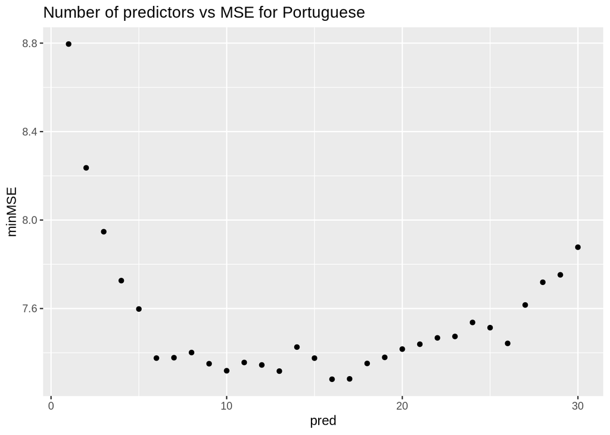

```r
data.frame(pred=1:maxPreds,minMSE) %>%
  ggplot()+
  geom_point(aes(pred,minMSE)) +
  ggtitle("Number of predictors vs MSE for Portuguese")
```

Here are the predictors in the subset with the lowest MSE for Portuguese

```r
bestPreds <- currPreds[1:which.min(minMSE)]
(bestPredNames <- names(d2_subset)[currPreds[1:which.min(minMSE)]])
```

```
##  [1] "failures"   "school"     "higher"     "Walc"       "schoolsup"
##  [6] "studytime"  "Pstatus"    "absences"   "Medu"       "guardian"
## [11] "address"    "age"        "activities" "health"     "paid"
## [16] "famsize"
```

## Random Forests and Variable Importance

```r
# create dataframes, clean
d1.bin = d1
d1.bin$pass = factor(ifelse(d1$G3 >= 10, "yes", "no"))
d2.bin = d2
d2.bin$pass = factor(ifelse(d2$G3 >= 10, "yes", "no"))
d1.bin = subset(d1.bin, select = -c(G1,G2,G3))
d2.bin = subset(d2.bin, select = -c(G1,G2,G3))

# make the models!
p <- ncol(d1.bin)
mod.bag.d1 <- randomForest(pass~.,
                         data=d1.bin,
                         mtry=p, ##use all the predictors
                         ntree=100) ## 100 trees

mod.bag.d2 <- randomForest(pass~.,
                         data=d2.bin,
                         mtry=p, ##use all the predictors
                         ntree=100) ## 100 trees
```

Let’s take a look at what was important for the math students.

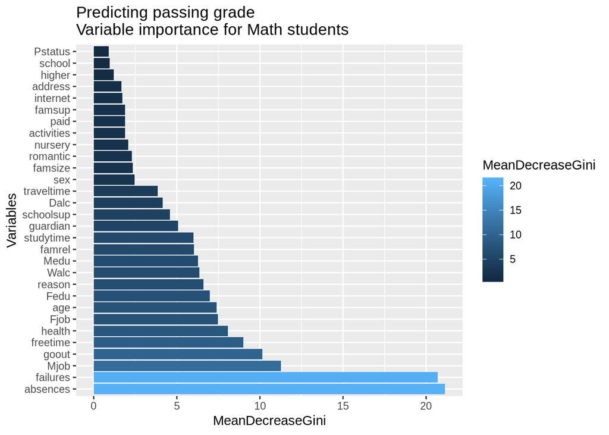

```r
temp1 = data.frame(importance(mod.bag.d1))
ggplot(data = temp1, aes(x=reorder(row.names(temp1), -MeanDecreaseGini),
                         y=MeanDecreaseGini, fill=MeanDecreaseGini)) +
  geom_bar(position="dodge",stat="identity") +
  coord_flip() +
  labs(title="Predicting passing grade\nVariable importance for Math students", x="Variables")
```

Absences and failures are very important in predicting whether a student passes or not. That makes a lot of sense! Let’s look at what happens with the Portuguese data set.

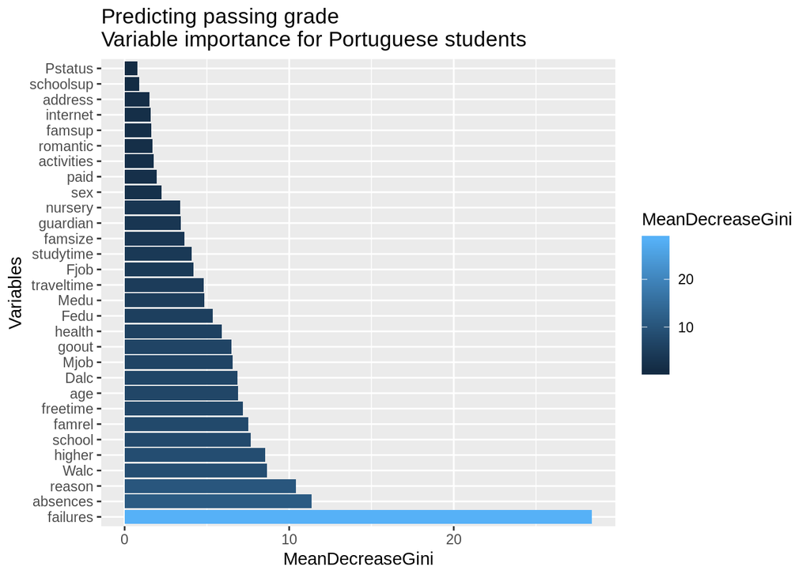

```r
temp2 = data.frame(importance(mod.bag.d2))
ggplot(data = temp2, aes(x=reorder(row.names(temp2), -MeanDecreaseGini),
                         y=MeanDecreaseGini, fill=MeanDecreaseGini)) +
  geom_bar(position="dodge",stat="identity") +
  coord_flip() +
  labs(title="Predicting passing grade\nVariable importance for Portuguese students", x="Variables")
```

Again, absences and failures account for a lot of the random forest’s decisions. It’s interesting to note that this random forest model agrees with what we saw in PCA, that failures and final grades were in opposite directions on the same “dimension”.

We are also interested in predicting things about students other than their grades like which school they attended, their gender, or whether or not they plan to go into higher education. We attempted to create models using random forests to answer these questions on both data sets. Much like our difficulties with k-means clustering, we did not have too much success in prediction. This was partially due to how certain attributes we nearly all the same among students (i.e. nearly all students didn’t have supplemental instruction in Portuguese). However, we still found interesting results from the variable importance plots for certain models, which we explore below.

### Predicting internet access at home

First, we build random forests for the math and Portuguese data sets.

```r
p <- ncol(d1)
mod.bag.d1 <- randomForest(internet~.,
                         data=d1,
                         mtry=p, ##use all the predictors
                         ntree=100) ## 100 trees

mod.bag.d2 <- randomForest(internet~.,
                         data=d2,
                         mtry=p, ##use all the predictors
                         ntree=100) ## 100 trees
```

Let’s take a look at the variable importance for our model on the math set.

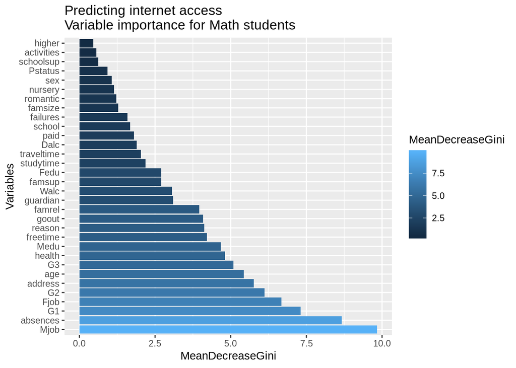

It appears that the mother’s job has a large influence over whether or not the household has access to internet, as seen in the “Mjob” attribute having the highest MeanDecreaseGini. “Fjob” also has high importance in the model, although definitely not quite as strong. Perhaps this could be explained from certain households having more income available to pay internet bills.

Let’s take a look at the model for the Portuguese class.

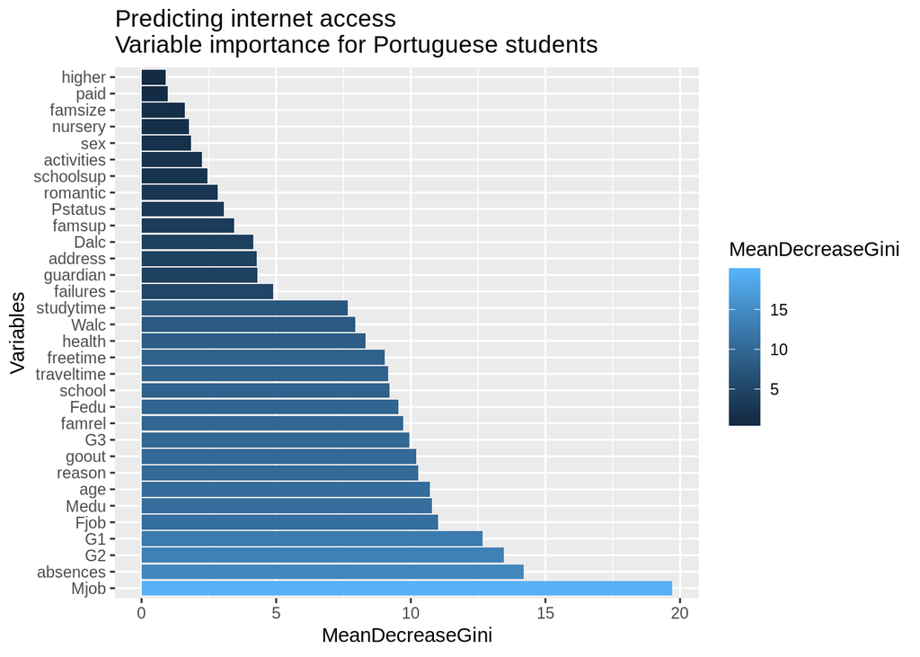

Again, it appears that the mother’s job plays a large role in our model. Here, the course grades also appear to be semi-important predictors. One possible reason for this would be that students with access to internet at home access more written material that interests them (online news, articles, forums, etc.)

In both models, the “absences” attribute seems to hold relatively high importance as well.

### Predicting school

Using random forests to predict which school a student attends also yields some interesting variable importance plots. We begin by building our models.

```r
p <- ncol(d1)
mod.bag.d1 <- randomForest(school~.,
                         data=d1,
                         mtry=p, ##use all the predictors
                         ntree=100) ## 100 trees

mod.bag.d2 <- randomForest(school~.,
                         data=d2,
                         mtry=p, ##use all the predictors
                         ntree=100) ## 100 trees
```

Let’s take a look at the plot for the math class.

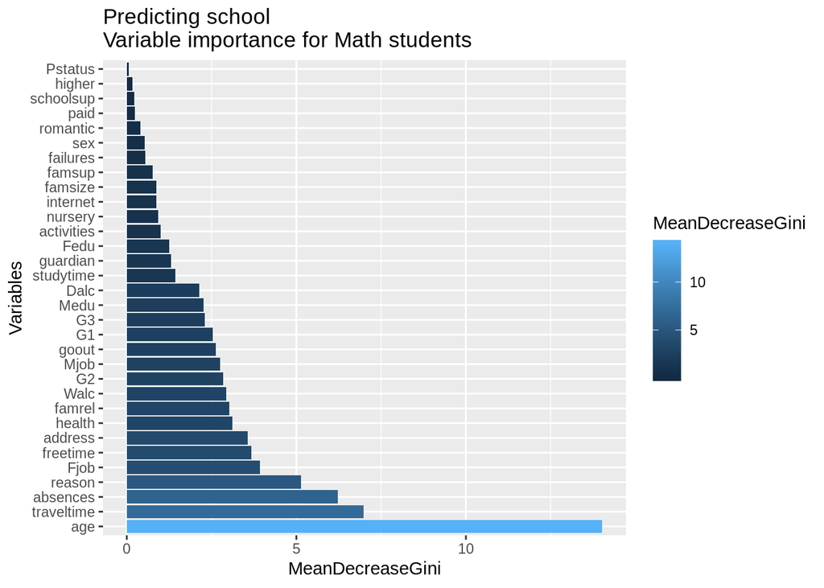

Age seems to play a large role in predicting the school. Why is this? Let’s take a look at some jitter plots for the math data set.

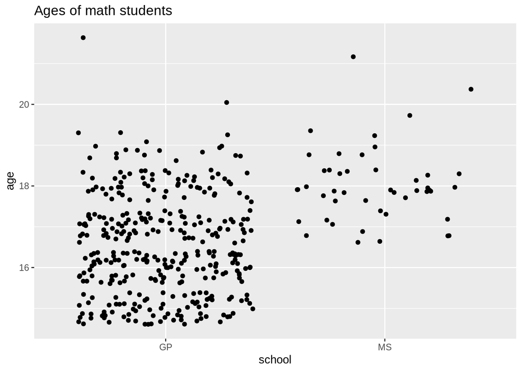

While the MS school has much fewer math students in general, it looks like the MS school has fewer young students for the math data set, which the random forest is picking up on.

Now let’s take a look at the Portuguese data set’s random forest variables.

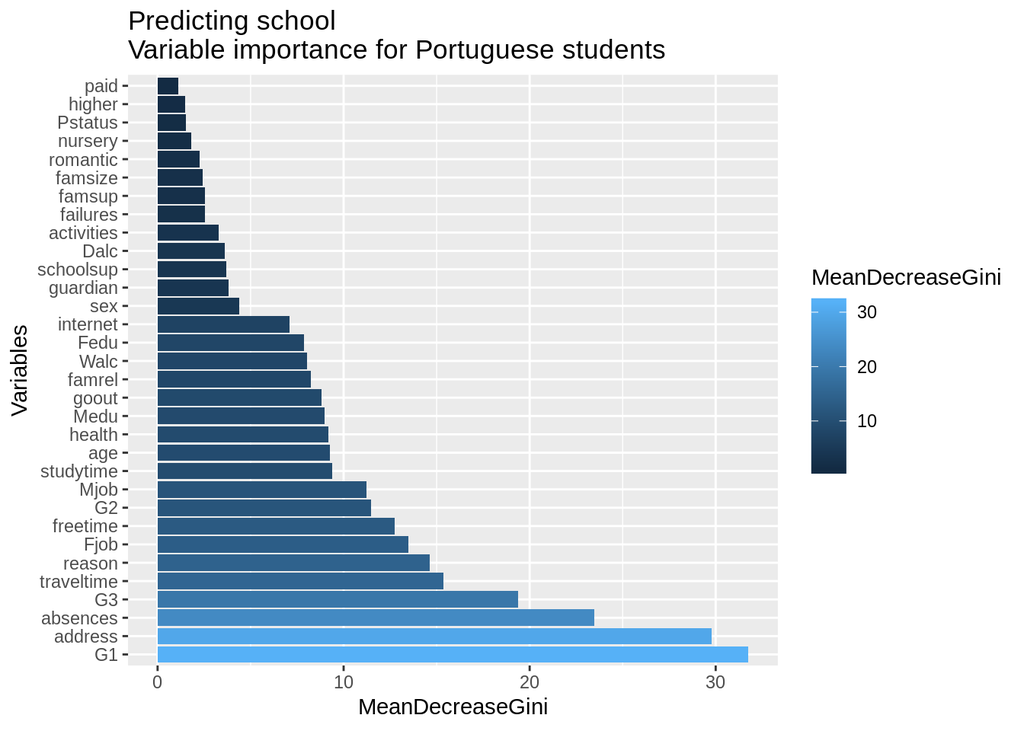

For the larger data set for the Portuguese class, address of the student (urban or rural) is a more important factor in determing school. This makes sense, since the MS school is located in a more rural area, while the GP school is more urban, as seen in the plot below.

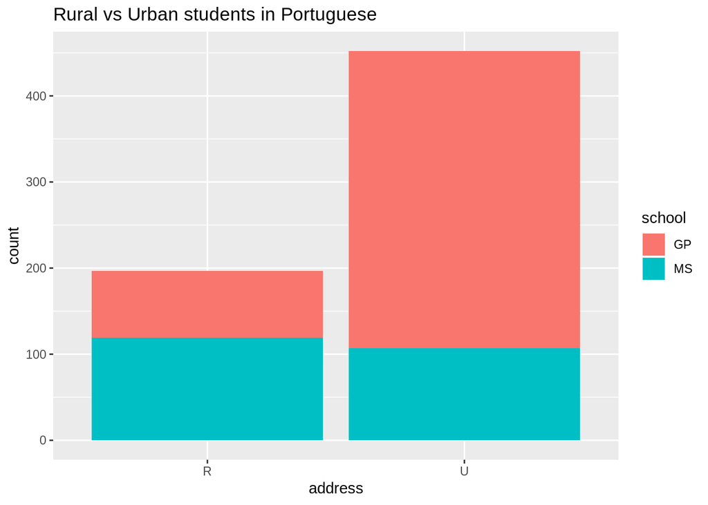

The variable importance plot suggests that the first grade (G1) is also an important predictor. Comparing the G1 grade across schools, it looks like the GP school has a slightly higher average grade, as seen below.

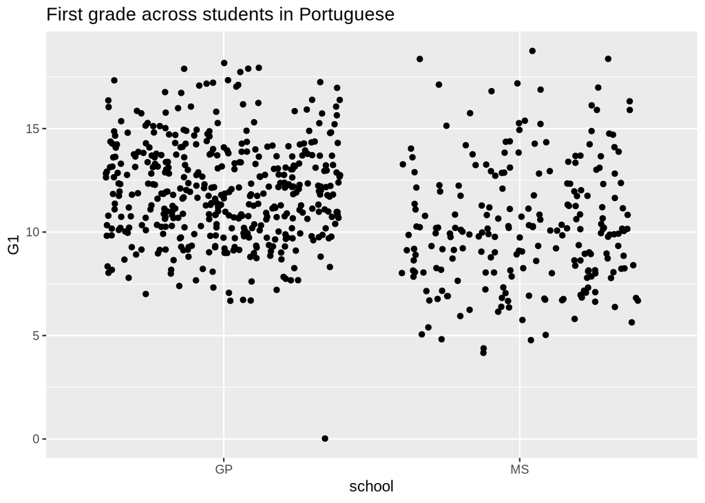

While the results of these random forests are not helpful for prediction, they give insight into the relationships between the predictors when classifying something other than grade. In addition, these explorations show another way one could extend the analysis of this data set.

# Conclusions

Instead of finding direct correlations between predictors and grade, we found that grouping the predictors yielded a more interesting and fruitful analysis. While different models gave different sets of variables, the groupings made sense in the context of the data set. Overall, while the models did not give us highly accurate predictions, we saw trends in the variables that were most helpful in predicting grades, such as number of previous failures, parents’ education, and student age. It is interesting that the different models have different results, which highlights how the choice of model greatly impacts that outcome and analysis, even while working with the same data.